# Why superhost is a superhost

**Why superhost is a superhost?**

-- Research on Airbnb Superhost Classifier and Feature Importance

*The estimated time for the entire notebook to run completely is about 35 seconds.*

**Introduction**

'Belong anywhere' is Airbnb's slogan and represents its corporate philosophy. Airbnb is an extension of the rental relationship, which can provide tenants with a more personalised and humanised living experience, and it also has the characteristics of quickness and convenience. However, unlike Airbnb's marketing strategy, a motivation-based study (Rimer, 2017) reveals that price-related factors are the primary reason people choose Airbnb, experiential motivations are on the back place. This makes it a new travel residence option that has an impact on the traditional accommodation industry. However, no matter how many different reasons people choose Airbnb as a rental for travel, and whether it is a substitute for a hotel, no people does not want to get a better stay during this period. How to choose the most suitable Airbnb rental, each tenant will have some reference when making a decision.

The 'Superhost' is an Airbnb's programme for celebrating and rewarding top-rated and most experienced hosts (Airbnb, 2019). According to Airbnb's introduction to this program, superhost can get more visibility, earning potential, and exclusive rewards. It is a reward mechanism for hosts that provide quality service. However, is the superhost's honorary title really directly and closely related to the outstanding hospitality?

Airbnb (2019) has four criteria for superhost: 4.8+ overall rating, 10+ stays, 0 cancellations and 90% response rate. The assessment is conducted every 3 months and the results are updated accordingly. The public data from Inside Airbnb (2019) contains relevant data for two of four standards: review rating and response rate. This research will not use the relevant data of the response rate. However, based on two considerations, research will choose to retain the data for the review rating section in the initial data cleanup. On the one hand, the rating data itself is composed of many other factors; on the other hand, rating data used in research has a different evaluation system than the overall rating in the criteria. In addition, the data also includes many other indicators.

The research selected Los Angeles as the representative city, using the latest data from March, which can be replaced with any other city with similar data. The raw data is an unprocessed csv file.

**Aims**

This research aims to identify the decisive factors (outside the assessment criteria) that become superhost through data analysis. According to relevant data comparison, choose a classifier that is relatively more advantageous to predict whether a host can become a superhost, and visualise the results.

Apart from that, the research results can provide support or assistance to Airbnb, host and tenants. First, for Airbnb, the results can help it improve the program, such as optimising the assessment criteria and the user search recommendation order. Next, for host, it can help them find ways to better obtain or keep superhost status, providing better stay for tenants. Then, for tenants, it can help them save time, get better options in the recommended list and have better stay experience. For the whole, this approach can form a reciprocal mechanism that better promotes a virtuous circle and benefits all three parties.

Research will undertake the structure as follows:

1. literature review
2. data import
3. basic data cleanup
4. location analysis
5. deep cleanup of non-geographically relevant data
6. data reorganisation
7. operation of the classifier and feature importance (including visualisation)
8. results comparison and conclusion

**Literature Review**

According to the study results of Rimer (2017), the top three reasons people tend to choose Airbnb as the rent are: price, minimum stays and age of guests. Guttentag (2016) analysed the different Airbnb tenants through classification discussion. In Guttentag's research, tenants were divided into five types for different rental purposes: money savers, home seekers, collaborative consumers, pragmatic novelty seekers and interactive novelty seekers. Five different types of tenants represent different priority demands. The requirements also correspond to the corresponding attributes of the rental. In addition, many studies on Airbnb mention and emphasise the competitive relationship between it and traditional hotels. Its competitive advantage is also a part that needs to be focused on in the analysis. Tenants with different purpose of travel (business or leisure) differ in their focus on competitive advantages (Nguyen, 2014). **In fact, due to the market environment, there is a relationship between whether the demand can be met and the review rating. Therefore, these related factors may also be an important factor in determining whether the host can become a superhost.**

'Sharing economy' is a concept that has recently been closely linked to Airbnb, and its internal driving force is a multi-win situation. Although the traditional hospitality industry has received negative economic impacts and shocks in the process, it provides better opportunities for resource allocation and utilisation for Airbnb and its customers, and creates new economic activities for the city (Quattrone, et al., 2016). Nguyen (2016) proposed three key points for Airbnb's sharing economy: 'alternative choices for customers looking to satisfy their needs'， 'personalized and socialized experiences' and 'shift in customer preferences'. This part is closely related to the tenant's demand described above, which is a proof for it.

Apart from that, the geographical factor as the most important factor in the choice of travel residence is not to be ignored. There is a correlation between the location of the location of travel residence and whether the guest chooses to book and their overall satisfaction (Tepavcevic, et al., 2016). And for the host, it is a basic condition that cannot be changed.

In most of the existing studies, the different factors are discussed separately and there is a lack of research that combines all factors. This research will combine these multiple features to give a more holistic analysis, and refer to some existing study to discuss the final results.

**Libraries Import**

Importing relevant libraries for accessing basic data analysis packages.

```python
import numpy as np
import matplotlib.pyplot as plt
import pandas as pd

pd.set_option('display.max_rows', 300) # specifies number of rows to show
pd.options.display.float_format = '{:40,.4f}'.format # specifies default number format to 4 decimal places
plt.style.use('ggplot') # specifies that graphs should use ggplot styling
%matplotlib inline
```

**Data Import**

Import the raw csv file. The original data set used for the research contained multiple features with a number of different attributes. Before performing data analysis, it need to know the content of the data presented in different columns and the relevant factors corresponding to them.

```python
# loads csv data and sets up the DataFrame, using the Pandas (pd) libraries
listing = pd.read_csv('listings.csv')
listing.head()
```

```
C:\Program Files\Anaconda3\lib\site-packages\IPython\core\interactiveshell.py:2785: DtypeWarning: Columns (61,62) have mixed types. Specify dtype option on import or set low_memory=False.
  interactivity=interactivity, compiler=compiler, result=result)
```

|  | id | listing_url | scrape_id | last_scraped | name | summary | space | description | experiences_offered | neighborhood_overview | ... | instant_bookable | is_business_travel_ready | cancellation_policy | require_guest_profile_picture | require_guest_phone_verification | calculated_host_listings_count | calculated_host_listings_count_entire_homes | calculated_host_listings_count_private_rooms | calculated_host_listings_count_shared_rooms | reviews_per_month |
| --- | --- | --- | --- | --- | --- | --- | --- | --- | --- | --- | --- | --- | --- | --- | --- | --- | --- | --- | --- | --- | --- |
| 0 | 109 | https://www.airbnb.com/rooms/109 | 20190306202210 | 2019-03-07 | Amazing bright elegant condo park front *UPGRA... | *** Unit upgraded with new bamboo flooring, br... | *** Unit upgraded with new bamboo flooring, br... | *** Unit upgraded with new bamboo flooring, br... | none | NaN | ... | f | f | strict_14_with_grace_period | t | f | 1 | 1 | 0 | 0 | 0.0200 |
| 1 | 344 | https://www.airbnb.com/rooms/344 | 20190306202210 | 2019-03-07 | Family perfect;Pool;Near Studios! | This home is perfect for families; aspiring ch... | Cheerful & comfortable; near studios, amusemen... | This home is perfect for families; aspiring ch... | none | Quiet-yet-close to all the fun in LA! Hollywoo... | ... | t | f | flexible | f | f | 1 | 1 | 0 | 0 | 0.1200 |
| 2 | 2708 | https://www.airbnb.com/rooms/2708 | 20190306202210 | 2019-03-07 | Gold Memory Foam Bed & Breakfast in West Holly... | Our best memory foam pillows you'll ever sleep... | Flickering fireplace display heater. Decorate... | Our best memory foam pillows you'll ever sleep... | none | We are minutes away from the Mentor Language I... | ... | t | f | strict_14_with_grace_period | f | f | 2 | 0 | 2 | 0 | 0.2600 |
| 3 | 2732 | https://www.airbnb.com/rooms/2732 | 20190306202210 | 2019-03-07 | Zen Life at the Beach | NaN | This is a three story townhouse with the follo... | This is a three story townhouse with the follo... | none | NaN | ... | f | f | strict_14_with_grace_period | f | f | 2 | 1 | 1 | 0 | 0.1900 |
| 4 | 2864 | https://www.airbnb.com/rooms/2864 | 20190306202210 | 2019-03-06 | *Upscale Professional Home with Beautiful Studio* | Centrally located.... Furnished with 42 inch S... | The space is furnished with Thomasville furnit... | Centrally located.... Furnished with 42 inch S... | none | What makes the neighborhood unique is that the... | ... | f | f | strict_14_with_grace_period | f | f | 1 | 1 | 0 | 0 | nan |

5 rows × 106 columns

```python
# gets the full names of columns
print(listing.columns.values)
```

```
['id' 'listing_url' 'scrape_id' 'last_scraped' 'name' 'summary' 'space'
 'description' 'experiences_offered' 'neighborhood_overview' 'notes'
 'transit' 'access' 'interaction' 'house_rules' 'thumbnail_url'
 'medium_url' 'picture_url' 'xl_picture_url' 'host_id' 'host_url'
 'host_name' 'host_since' 'host_location' 'host_about'
 'host_response_time' 'host_response_rate' 'host_acceptance_rate'
 'host_is_superhost' 'host_thumbnail_url' 'host_picture_url'
 'host_neighbourhood' 'host_listings_count' 'host_total_listings_count'
 'host_verifications' 'host_has_profile_pic' 'host_identity_verified'
 'street' 'neighbourhood' 'neighbourhood_cleansed'
 'neighbourhood_group_cleansed' 'city' 'state' 'zipcode' 'market'
 'smart_location' 'country_code' 'country' 'latitude' 'longitude'
 'is_location_exact' 'property_type' 'room_type' 'accommodates'
 'bathrooms' 'bedrooms' 'beds' 'bed_type' 'amenities' 'square_feet'
 'price' 'weekly_price' 'monthly_price' 'security_deposit' 'cleaning_fee'
 'guests_included' 'extra_people' 'minimum_nights' 'maximum_nights'
 'minimum_minimum_nights' 'maximum_minimum_nights'
 'minimum_maximum_nights' 'maximum_maximum_nights'
 'minimum_nights_avg_ntm' 'maximum_nights_avg_ntm' 'calendar_updated'
 'has_availability' 'availability_30' 'availability_60' 'availability_90'
 'availability_365' 'calendar_last_scraped' 'number_of_reviews'
 'number_of_reviews_ltm' 'first_review' 'last_review'
 'review_scores_rating' 'review_scores_accuracy'
 'review_scores_cleanliness' 'review_scores_checkin'
 'review_scores_communication' 'review_scores_location'
 'review_scores_value' 'requires_license' 'license' 'jurisdiction_names'
 'instant_bookable' 'is_business_travel_ready' 'cancellation_policy'
 'require_guest_profile_picture' 'require_guest_phone_verification'
 'calculated_host_listings_count'
 'calculated_host_listings_count_entire_homes'
 'calculated_host_listings_count_private_rooms'
 'calculated_host_listings_count_shared_rooms' 'reviews_per_month']
```

**Basic Data Cleanup**

In order to ensure that the subsequent analysis can proceed smoothly and the results are not affected, the first thing to do is removing the line that does not give whether the host is superhost. The cleaned up data contains 43192 sets of host data, of which 12189 hosts are superhost and the other 31003 are not.

```python
listing['host_is_superhost'] = listing['host_is_superhost'].astype(str)
listing = listing[listing.host_is_superhost != 'nan']
listing = listing.fillna('')
listing.head()
```

|  | id | listing_url | scrape_id | last_scraped | name | summary | space | description | experiences_offered | neighborhood_overview | ... | instant_bookable | is_business_travel_ready | cancellation_policy | require_guest_profile_picture | require_guest_phone_verification | calculated_host_listings_count | calculated_host_listings_count_entire_homes | calculated_host_listings_count_private_rooms | calculated_host_listings_count_shared_rooms | reviews_per_month |
| --- | --- | --- | --- | --- | --- | --- | --- | --- | --- | --- | --- | --- | --- | --- | --- | --- | --- | --- | --- | --- | --- |
| 0 | 109 | https://www.airbnb.com/rooms/109 | 20190306202210 | 2019-03-07 | Amazing bright elegant condo park front *UPGRA... | *** Unit upgraded with new bamboo flooring, br... | *** Unit upgraded with new bamboo flooring, br... | *** Unit upgraded with new bamboo flooring, br... | none |  | ... | f | f | strict_14_with_grace_period | t | f | 1 | 1 | 0 | 0 | 0.0200 |
| 1 | 344 | https://www.airbnb.com/rooms/344 | 20190306202210 | 2019-03-07 | Family perfect;Pool;Near Studios! | This home is perfect for families; aspiring ch... | Cheerful & comfortable; near studios, amusemen... | This home is perfect for families; aspiring ch... | none | Quiet-yet-close to all the fun in LA! Hollywoo... | ... | t | f | flexible | f | f | 1 | 1 | 0 | 0 | 0.1200 |
| 2 | 2708 | https://www.airbnb.com/rooms/2708 | 20190306202210 | 2019-03-07 | Gold Memory Foam Bed & Breakfast in West Holly... | Our best memory foam pillows you'll ever sleep... | Flickering fireplace display heater. Decorate... | Our best memory foam pillows you'll ever sleep... | none | We are minutes away from the Mentor Language I... | ... | t | f | strict_14_with_grace_period | f | f | 2 | 0 | 2 | 0 | 0.2600 |
| 3 | 2732 | https://www.airbnb.com/rooms/2732 | 20190306202210 | 2019-03-07 | Zen Life at the Beach |  | This is a three story townhouse with the follo... | This is a three story townhouse with the follo... | none |  | ... | f | f | strict_14_with_grace_period | f | f | 2 | 1 | 1 | 0 | 0.1900 |
| 4 | 2864 | https://www.airbnb.com/rooms/2864 | 20190306202210 | 2019-03-06 | *Upscale Professional Home with Beautiful Studio* | Centrally located.... Furnished with 42 inch S... | The space is furnished with Thomasville furnit... | Centrally located.... Furnished with 42 inch S... | none | What makes the neighborhood unique is that the... | ... | f | f | strict_14_with_grace_period | f | f | 1 | 1 | 0 | 0 |  |

5 rows × 106 columns

```python
listing.groupby(['host_is_superhost']).size()
```

```
host_is_superhost
f    31003
t    12189
dtype: int64
```

**Location Analysis**

Geographic factors will first be analysed separately from other features for two reasons. First, destinations have a very important and decisive influence on travel that is different from other factors. Although all rentals are in the same city, regardless of whether the tenant's travel is for business or leisure, location is one of their top priorities because of the consideration of the transport cost within the destination city. Location is also the primary key search condition on the Airbnb website to provide search services to tenants. Second, because the properties of location data have certain peculiarities (latitude and longitude coordinates), it is difficult to classify and discuss with other data. However, it is necessary to pay attention to whether the geographical data will have a very important impact on the results. If it affects the distribution of superhost, it is necessary to eliminate interference as much as possible in the discussion of other factors. Using a scatter plot with different colours can simply observe the distribution of the superhosts and other hosts.

First, select geographically related columns to form a new DataFrame.

```python
loc = listing[['id','zipcode','latitude','longitude','host_is_superhost']]
loc = loc.set_index('id')
loc.head()
```

| id | zipcode | latitude | longitude | host_is_superhost |
| --- | --- | --- | --- | --- |
| 109 | 90230 | 33.9821 | -118.3849 | f |
| 344 | 91505 | 34.1656 | -118.3346 | f |
| 2708 | 90046 | 34.0977 | -118.3460 | t |
| 2732 | 90405 | 34.0048 | -118.4813 | f |
| 2864 | 90706 | 33.8762 | -118.1140 | f |

**Projection**

Since the geographic coordinates in the original data cannot directly correspond to the coordinates of the base map, the original coordinates need to be projected before producing scatter plot, so that the points of rentals can be better presented on a flat 2-dimensional plane. When converting latitude and longitude coordinates to tuple of X and Y coordinates, this research choose to done the projection here using the function provided by Reid (2018).

```python
# creates function
import math
from ast import literal_eval
def merc(Coords):
    Coordinates = literal_eval(Coords)
    lat = Coordinates[0]
    lon = Coordinates[1]

    r_major = 6378137.000
    x = r_major * math.radians(lon)
    scale = x/lon
    y = 180.0/math.pi * math.log(math.tan(math.pi/4.0 +
        lat * (math.pi/180.0)/2.0)) * scale
    return (x, y)
```

```python
# converts latitude and longitude coordinates to a format that can be recognized by function
loc['Location'] = '(' + loc['latitude'].astype(str) + ',' + loc['longitude'].astype(str) + ')'
loc.head()
```

| id | zipcode | latitude | longitude | host_is_superhost | Location |
| --- | --- | --- | --- | --- | --- |
| 109 | 90230 | 33.9821 | -118.3849 | f | (33.98209,-118.38493999999999) |
| 344 | 91505 | 34.1656 | -118.3346 | f | (34.165620000000004,-118.33458) |
| 2708 | 90046 | 34.0977 | -118.3460 | t | (34.09768,-118.34602) |
| 2732 | 90405 | 34.0048 | -118.4813 | f | (34.00475,-118.48127) |
| 2864 | 90706 | 33.8762 | -118.1140 | f | (33.87619,-118.11397) |

```python
# converts coordinates to the final desired format
loc['coords_x'] = loc['Location'].apply(lambda x: merc(x)[0])
loc['coords_y'] = loc['Location'].apply(lambda x: merc(x)[1])
```

```python
loc['coords_x'].describe()
```

```
count                                43,192.0000
mean                            -13,172,002.2831
std                                  16,968.0925
min                             -13,239,696.8083
25%                             -13,182,694.5498
50%                             -13,173,949.2906
75%                             -13,164,829.4414
max                             -13,097,031.9753
Name: coords_x, dtype: float64
```

```python
loc['coords_y'].describe()
```

```
count                                43,192.0000
mean                              4,036,159.3302
std                                  15,523.4034
min                               3,940,318.1866
25%                               4,030,239.8724
50%                               4,037,442.5758
75%                               4,042,701.3065
max                               4,138,252.1301
Name: coords_y, dtype: float64
```

**Map Plot**

After obtaining the maximum and minimum values of 'coords_x' and 'coords_y', the range of the map display area is determined. After setting the relevant properties of the map, a scatter plot that is distinguished by the red and blue colours can be obtained. The red dot indicates that host is not superhost, and the blue dot indicates that host is superhost.

```python
from bokeh.models import BoxZoomTool
from bokeh.plotting import figure, output_notebook, show

output_notebook()

LA = x_range, y_range = ((-13300000,-13000000), (3940000,4050000))

plot_width  = int(750)
plot_height = int(plot_width//1.2)

# base map setting
def base_plot(tools='pan,wheel_zoom,reset',plot_width=plot_width, plot_height=plot_height, **plot_args):
    p = figure(tools=tools, plot_width=plot_width, plot_height=plot_height,
        x_range=x_range, y_range=y_range, outline_line_color=None,
        min_border=0, min_border_left=0, min_border_right=0,
        min_border_top=0, min_border_bottom=0, **plot_args)

    p.axis.visible = False
    p.xgrid.grid_line_color = None
    p.ygrid.grid_line_color = None

    p.add_tools(BoxZoomTool(match_aspect=True))

    return p

cols = [] # color setting
for a in loc['host_is_superhost']:
    if a=="f":
        cols.append("red")
    elif a=="t":
        cols.append("blue")
options = dict(line_color=None, fill_color=cols, size=1)
```

```python
from bokeh.tile_providers import CARTODBPOSITRON

p = base_plot()
p.add_tile(CARTODBPOSITRON) # add base map
p.circle(x=loc['coords_x'].tolist(), y=loc['coords_y'].tolist(), **options) # scatter plot
show(p)
```

[interactive chart not shown]

By observing the scatter plot, it can be known that the distribution of the rental has a certain degree of aggregation on the whole, the centre position and the coastal position are densely distributed, and the edge position distribution is sparse. However, superhost and other host's rental do not form obvious clusters in geographical distribution. Therefore, geography is not a decisive factor in whether host can become a superhost. In the subsequent discussion of features, geographical factors will no longer be analysed.

**Deep Cleanup of Non-geographically Relevant Data**

Before analysing non-geographic factors, it need to do more careful data cleanup first. The simple idea of cleaning up is first to remove columns that are completely unusable or irrelevant in the original data.

```python
cl = listing[['id','host_is_superhost','host_verifications','host_has_profile_pic','host_identity_verified','is_location_exact',
              'property_type','room_type','accommodates','bathrooms','bedrooms','beds','bed_type','amenities','price',
              'cleaning_fee','guests_included','extra_people','minimum_nights','maximum_nights','number_of_reviews',
              'review_scores_rating','review_scores_accuracy','review_scores_cleanliness','review_scores_checkin',
              'review_scores_communication','review_scores_location','review_scores_value','requires_license',
              'instant_bookable','cancellation_policy','require_guest_profile_picture','require_guest_phone_verification',
              'calculated_host_listings_count','calculated_host_listings_count_entire_homes',
              'calculated_host_listings_count_private_rooms','calculated_host_listings_count_shared_rooms','reviews_per_month']]
cl.head()
```

|  | id | host_is_superhost | host_verifications | host_has_profile_pic | host_identity_verified | is_location_exact | property_type | room_type | accommodates | bathrooms | ... | requires_license | instant_bookable | cancellation_policy | require_guest_profile_picture | require_guest_phone_verification | calculated_host_listings_count | calculated_host_listings_count_entire_homes | calculated_host_listings_count_private_rooms | calculated_host_listings_count_shared_rooms | reviews_per_month |
| --- | --- | --- | --- | --- | --- | --- | --- | --- | --- | --- | --- | --- | --- | --- | --- | --- | --- | --- | --- | --- | --- |
| 0 | 109 | f | ['email', 'phone', 'facebook', 'reviews', 'kba'] | t | t | t | Condominium | Entire home/apt | 6 | 2.0000 | ... | f | f | strict_14_with_grace_period | t | f | 1 | 1 | 0 | 0 | 0.0200 |
| 1 | 344 | f | ['email', 'phone', 'reviews', 'jumio', 'kba', ... | t | t | t | House | Entire home/apt | 6 | 1.0000 | ... | f | t | flexible | f | f | 1 | 1 | 0 | 0 | 0.1200 |
| 2 | 2708 | t | ['email', 'phone', 'facebook', 'reviews', 'kba'] | t | t | t | Apartment | Private room | 1 | 1.5000 | ... | f | t | strict_14_with_grace_period | f | f | 2 | 0 | 2 | 0 | 0.2600 |
| 3 | 2732 | f | ['email', 'phone', 'reviews', 'jumio', 'offlin... | t | f | t | Apartment | Private room | 1 | 1.0000 | ... | t | f | strict_14_with_grace_period | f | f | 2 | 1 | 1 | 0 | 0.1900 |
| 4 | 2864 | f | ['email', 'phone', 'facebook', 'kba'] | t | t | t | Apartment | Entire home/apt | 2 | 1.0000 | ... | f | f | strict_14_with_grace_period | f | f | 1 | 1 | 0 | 0 |  |

5 rows × 38 columns

Next, convert the price-related values into numeric attributes that can be calculated, and perform simple calculation to get the new two columns needed: 'total_price' and 'per_person_price'.

```python
cl['price'] = cl['price'].str.replace('$','')
cl['price'] = cl['price'].str.replace(',','')
cl['price'] = pd.to_numeric(cl['price'])

cl['cleaning_fee'] = cl['cleaning_fee'].str.replace('$','')
cl['cleaning_fee'] = cl['cleaning_fee'].str.replace(',','')
cl['cleaning_fee'] = pd.to_numeric(cl['cleaning_fee'])

cl['extra_people'] = cl['extra_people'].str.replace('$','')
cl['extra_people'] = cl['extra_people'].str.replace(',','')
cl['extra_people'] = pd.to_numeric(cl['extra_people'])
```

[output not shown]

```python
cl['total_price']=cl['price']+cl['cleaning_fee']
cl['per_person_price']=cl['total_price']/cl['guests_included']
```

[output not shown]

Then, convert two columns ('host_verifications' and 'amenities') containing a number of different separated and messy content descriptions into statistical count values.

```python
cl['host_verifications_count'] = cl['host_verifications'].str.count("'")/2
cl['host_verifications_count'] = cl['host_verifications_count'].astype(int)

cl['amenities_count'] = cl['amenities'].str.count(',')+1
```

[output not shown]

```python
cl.head()
```

|  | id | host_is_superhost | host_verifications | host_has_profile_pic | host_identity_verified | is_location_exact | property_type | room_type | accommodates | bathrooms | ... | require_guest_phone_verification | calculated_host_listings_count | calculated_host_listings_count_entire_homes | calculated_host_listings_count_private_rooms | calculated_host_listings_count_shared_rooms | reviews_per_month | total_price | per_person_price | host_verifications_count | amenities_count |
| --- | --- | --- | --- | --- | --- | --- | --- | --- | --- | --- | --- | --- | --- | --- | --- | --- | --- | --- | --- | --- | --- |
| 0 | 109 | f | ['email', 'phone', 'facebook', 'reviews', 'kba'] | t | t | t | Condominium | Entire home/apt | 6 | 2.0000 | ... | f | 1 | 1 | 0 | 0 | 0.0200 | 362.0000 | 120.6667 | 5 | 32 |
| 1 | 344 | f | ['email', 'phone', 'reviews', 'jumio', 'kba', ... | t | t | t | House | Entire home/apt | 6 | 1.0000 | ... | f | 1 | 1 | 0 | 0 | 0.1200 | 268.0000 | 44.6667 | 6 | 41 |
| 2 | 2708 | t | ['email', 'phone', 'facebook', 'reviews', 'kba'] | t | t | t | Apartment | Private room | 1 | 1.5000 | ... | f | 2 | 0 | 2 | 0 | 0.2600 | 164.0000 | 164.0000 | 5 | 43 |
| 3 | 2732 | f | ['email', 'phone', 'reviews', 'jumio', 'offlin... | t | f | t | Apartment | Private room | 1 | 1.0000 | ... | f | 2 | 1 | 1 | 0 | 0.1900 | 240.0000 | 240.0000 | 6 | 12 |
| 4 | 2864 | f | ['email', 'phone', 'facebook', 'kba'] | t | t | t | Apartment | Entire home/apt | 2 | 1.0000 | ... | f | 1 | 1 | 0 | 0 |  | 155.0000 | 155.0000 | 4 | 20 |

5 rows × 42 columns

Finally, remove the unprocessed columns which are not needed for analysis, and reorder the remaining columns. And separate the column that does not contain the label, only contains the attribute from the original DataFrame to form a new DataFrame.

```python
choose_data = cl[['id','host_verifications_count','host_has_profile_pic','host_identity_verified','is_location_exact',
                  'property_type','room_type','bathrooms','bedrooms','beds','bed_type','amenities_count',
                  'price','cleaning_fee','total_price','guests_included','extra_people','per_person_price',
                  'minimum_nights','maximum_nights','number_of_reviews','reviews_per_month',
                  'review_scores_rating','review_scores_accuracy','review_scores_cleanliness','review_scores_checkin',
                  'review_scores_communication','review_scores_location','review_scores_value',
                  'requires_license','instant_bookable','cancellation_policy',
                  'require_guest_profile_picture','require_guest_phone_verification',
                  'calculated_host_listings_count','calculated_host_listings_count_entire_homes',
                  'calculated_host_listings_count_private_rooms','calculated_host_listings_count_shared_rooms',
                  'host_is_superhost']]
```

```python
# get attribute DataFrame
data = choose_data.drop(columns=['host_is_superhost'])
data = data.set_index('id')
data.head()
```

| id | host_verifications_count | host_has_profile_pic | host_identity_verified | is_location_exact | property_type | room_type | bathrooms | bedrooms | beds | bed_type | ... | review_scores_value | requires_license | instant_bookable | cancellation_policy | require_guest_profile_picture | require_guest_phone_verification | calculated_host_listings_count | calculated_host_listings_count_entire_homes | calculated_host_listings_count_private_rooms | calculated_host_listings_count_shared_rooms |
| --- | --- | --- | --- | --- | --- | --- | --- | --- | --- | --- | --- | --- | --- | --- | --- | --- | --- | --- | --- | --- | --- |
| 109 | 5 | t | t | t | Condominium | Entire home/apt | 2.0000 | 2.0000 | 3.0000 | Real Bed | ... | 8.0000 | f | f | strict_14_with_grace_period | t | f | 1 | 1 | 0 | 0 |
| 344 | 6 | t | t | t | House | Entire home/apt | 1.0000 | 3.0000 | 3.0000 | Real Bed | ... | 9.0000 | f | t | flexible | f | f | 1 | 1 | 0 | 0 |
| 2708 | 5 | t | t | t | Apartment | Private room | 1.5000 | 1.0000 | 1.0000 | Real Bed | ... | 10.0000 | f | t | strict_14_with_grace_period | f | f | 2 | 0 | 2 | 0 |
| 2732 | 6 | t | f | t | Apartment | Private room | 1.0000 | 1.0000 | 1.0000 | Pull-out Sofa | ... | 9.0000 | t | f | strict_14_with_grace_period | f | f | 2 | 1 | 1 | 0 |
| 2864 | 4 | t | t | t | Apartment | Entire home/apt | 1.0000 | 1.0000 | 1.0000 | Real Bed | ... |  | f | f | strict_14_with_grace_period | f | f | 1 | 1 | 0 | 0 |

5 rows × 37 columns

```python
len(data.columns)
```

```
37
```

**Autocorrelation Analysis of Digital Features**

Some of the current attributes of columns that should be numeric attributes are not correct and cannot be used correctly in autocorrelation analysis, which need to be converted first.

```python
data.dtypes
```

```
host_verifications_count                          int32
host_has_profile_pic                             object
host_identity_verified                           object
is_location_exact                                object
property_type                                    object
room_type                                        object
bathrooms                                        object
bedrooms                                         object
beds                                             object
bed_type                                         object
amenities_count                                   int64
price                                           float64
cleaning_fee                                    float64
total_price                                     float64
guests_included                                   int64
extra_people                                    float64
per_person_price                                float64
minimum_nights                                    int64
maximum_nights                                    int64
number_of_reviews                                 int64
reviews_per_month                                object
review_scores_rating                             object
review_scores_accuracy                           object
review_scores_cleanliness                        object
review_scores_checkin                            object
review_scores_communication                      object
review_scores_location                           object
review_scores_value                              object
requires_license                                 object
instant_bookable                                 object
cancellation_policy                              object
require_guest_profile_picture                    object
require_guest_phone_verification                 object
calculated_host_listings_count                    int64
calculated_host_listings_count_entire_homes       int64
calculated_host_listings_count_private_rooms      int64
calculated_host_listings_count_shared_rooms       int64
dtype: object
```

```python
data[['bathrooms','bedrooms','beds','cleaning_fee','total_price','extra_people','per_person_price','reviews_per_month',
      'review_scores_rating','review_scores_accuracy','review_scores_cleanliness','review_scores_checkin',
      'review_scores_communication','review_scores_location','review_scores_value',
      'calculated_host_listings_count','calculated_host_listings_count_entire_homes',
      'calculated_host_listings_count_private_rooms','calculated_host_listings_count_shared_rooms']] = data[['bathrooms','bedrooms','beds','cleaning_fee','total_price','extra_people','per_person_price','reviews_per_month',
      'review_scores_rating','review_scores_accuracy','review_scores_cleanliness','review_scores_checkin',
      'review_scores_communication','review_scores_location','review_scores_value',
      'calculated_host_listings_count','calculated_host_listings_count_entire_homes',
      'calculated_host_listings_count_private_rooms','calculated_host_listings_count_shared_rooms']].apply(pd.to_numeric, errors='coerce')
```

```python
import seaborn as sns
```

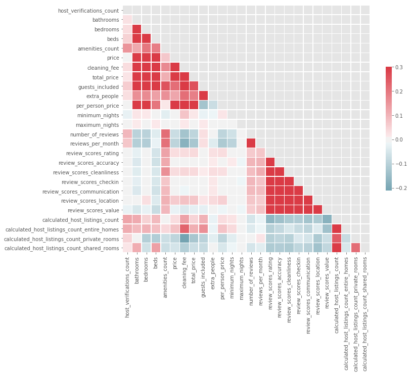

```python
# computes the correlation matrix
corr = data.corr()

# generates a mask for the upper triangle
mask = np.zeros_like(corr, dtype=np.bool)
mask[np.triu_indices_from(mask)] = True

# sets up the matplotlib figure
f, ax = plt.subplots(figsize=(11, 9))

# generates a custom diverging colormap
cmap = sns.diverging_palette(220, 10, as_cmap=True)

# draws the heatmap with the mask and correct aspect ratio
sns.heatmap(corr, mask=mask, cmap=cmap, vmax=.3, center=0,
            square=True, annot=False, fmt='.2f',linewidths=.5,
            cbar_kws={"shrink": .5})
```

By observing the correlation matrix, it can be found that there are highly correlated features in the selected features that need to be selectively removed. High correlations are concentrated in three aspects: amenities, prices and reviews.

First, for the three related columns of the amenities, since 'beds' have a certain overlapping relationship with 'bedrooms' and 'bed_type', so here choose to remove the 'beds' column.

Second, the columns that were removed in aspects of price are 'price', 'cleaning_fee' and 'total_price', because 'per_person_price' is calculated jointly by them.

Third, 'reviews_per_month' is removed in 'number_of_reviews' and 'reviews_per_month'. The reason is that 'reviews_per_month' is more relevant to the three-month assessment cycle. The six 'review_scores' related sub-features and the 'review_scores_ratings' also show a high autocorrelation. On the one hand, 'review_scores_ratings' itself is closely related to the 6 sub-features. On the other hand, this also reflects the tenant's review habits. **Tenants usually give a consistent reviews on each sub-feature and the overall rating.** This situation proves from one side that the host that obtains good review often has no obvious shortcomings in all aspects, and the host that gets bad review does not necessarily do poorly in every aspect. Only 'review_scores_ratings' will be retained in subsequent analysis of this research.

After removing columns with high correlation, all unknown data in the DataFrame is uniformly converted to 'dn'.

```python
data = data.drop(columns=['beds','price','cleaning_fee','total_price','reviews_per_month',
                          'review_scores_accuracy','review_scores_cleanliness','review_scores_checkin',
                          'review_scores_communication','review_scores_location','review_scores_value'])
data = data.fillna('dn')
data.head()
```

| id | host_verifications_count | host_has_profile_pic | host_identity_verified | is_location_exact | property_type | room_type | bathrooms | bedrooms | bed_type | amenities_count | ... | review_scores_rating | requires_license | instant_bookable | cancellation_policy | require_guest_profile_picture | require_guest_phone_verification | calculated_host_listings_count | calculated_host_listings_count_entire_homes | calculated_host_listings_count_private_rooms | calculated_host_listings_count_shared_rooms |
| --- | --- | --- | --- | --- | --- | --- | --- | --- | --- | --- | --- | --- | --- | --- | --- | --- | --- | --- | --- | --- | --- |
| 109 | 5 | t | t | t | Condominium | Entire home/apt | 2.0000 | 2.0000 | Real Bed | 32 | ... | 80.0000 | f | f | strict_14_with_grace_period | t | f | 1 | 1 | 0 | 0 |
| 344 | 6 | t | t | t | House | Entire home/apt | 1.0000 | 3.0000 | Real Bed | 41 | ... | 93.0000 | f | t | flexible | f | f | 1 | 1 | 0 | 0 |
| 2708 | 5 | t | t | t | Apartment | Private room | 1.5000 | 1.0000 | Real Bed | 43 | ... | 97.0000 | f | t | strict_14_with_grace_period | f | f | 2 | 0 | 2 | 0 |
| 2732 | 6 | t | f | t | Apartment | Private room | 1.0000 | 1.0000 | Pull-out Sofa | 12 | ... | 96.0000 | t | f | strict_14_with_grace_period | f | f | 2 | 1 | 1 | 0 |
| 2864 | 4 | t | t | t | Apartment | Entire home/apt | 1.0000 | 1.0000 | Real Bed | 20 | ... | dn | f | f | strict_14_with_grace_period | f | f | 1 | 1 | 0 | 0 |

5 rows × 26 columns

```python
len(data.columns)
```

```
26
```

**Create Equivalent Label Dataset**

Use LabelEncoder to convert 'host_is_superhost' to a format that the classifier can handle. The le encoder can be used for reverse encoding.

```python
from sklearn.preprocessing import LabelEncoder
```

```python
le = LabelEncoder() # creates the LabelEncoder object
labels_fea = le.fit_transform(choose_data['host_is_superhost']) # runs LabelEncoder on the 'host_is_superhost column'
```

```python
le.classes_
```

```
array(['f', 't'], dtype=object)
```

**Converting Each Categorical Attribute into Additional Boolean Columns**

Since the data in many non-digital related columns contains more than two type's content, the original 26 columns are expanded into 94 new columns.

```python
from sklearn.feature_extraction import DictVectorizer
```

```python
data_dict = data.to_dict('records')
```

```python
vec = DictVectorizer()  # create the DictVectorizer object
vec_data = vec.fit_transform(data_dict)  # execute process on the record dictionaries
```

```python
vec_data
```

```
<43192x94 sparse matrix of type '<class 'numpy.float64'>'
	with 1010456 stored elements in Compressed Sparse Row format>
```

```python
vec_name = vec.get_feature_names()
len(vec_name)
```

```
94
```

```python
vec_array = vec_data.toarray()
```

**Training and Testing Subsets Split**

The last operation before classification and feature importance analysis is to split the prepared dataset into training and testing subsets. The split training set will be used for analytical learning and the testing set will be used for result prediction. The ratio between the two set is 4:1.

```python
from sklearn.cross_validation import train_test_split
```

```
C:\Program Files\Anaconda3\lib\site-packages\sklearn\cross_validation.py:41: DeprecationWarning: This module was deprecated in version 0.18 in favor of the model_selection module into which all the refactored classes and functions are moved. Also note that the interface of the new CV iterators are d…
  "This module will be removed in 0.20.", DeprecationWarning)
```

```python
train_d, test_d, train_lab, test_lab = train_test_split(vec_array, labels_fea, test_size=0.20)
```

```python
len(train_d),len(test_d),len(train_lab),len(test_lab)
```

```
(34553, 8639, 34553, 8639)
```

**Operation of the Classifier and Feature Importance**

Considering many factors such as speed and accuracy, the research selected two of the many classifiers for testing and comparison. They are Decision Tree Classifier and Random Forest Classifier.

After the training set is processed using the classifier, the testing set results are directly predicted and the accuracy of the predictions is given. Thereafter, the research will use the confusion matrix and classification report to perform a more detailed analysis of the predictions.

The analysis of feature importance and corresponding ranking is also presented in this section, and the visualisation will show a bar chart of features with importance greater than 0.001.

**Decision Tree Classifier**

```python
from sklearn.tree import DecisionTreeClassifier
```

```python
tree = DecisionTreeClassifier()
tree.fit(train_d, train_lab)
```

```
DecisionTreeClassifier(class_weight=None, criterion='gini', max_depth=None,
            max_features=None, max_leaf_nodes=None,
            min_impurity_decrease=0.0, min_impurity_split=None,
            min_samples_leaf=1, min_samples_split=2,
            min_weight_fraction_leaf=0.0, presort=False, random_state=None,
            splitter='best')
```

```python
tree.score(test_d, test_lab)
```

```
0.7887486977659451
```

```python
predictions = tree.predict(test_d)
predicted = pd.DataFrame(list(le.inverse_transform(predictions)))
test_data = pd.DataFrame(list(le.inverse_transform(test_lab)))
test_data.rename(columns={0: 'host_is_superhost'}, inplace=True)
result=pd.concat([test_data,predicted],axis=1)
result.rename(columns={0: 'predicted'}, inplace=True)
result.head()
```

[output not shown]

|  | host_is_superhost | predicted |
| --- | --- | --- |
| 0 | f | f |
| 1 | f | f |
| 2 | f | f |
| 3 | f | f |
| 4 | f | f |

```python
from sklearn import metrics
confusion_matrix = metrics.confusion_matrix(test_lab, predictions)
```

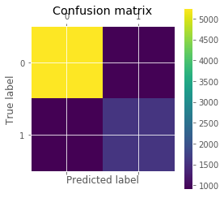

```python
plt.matshow(confusion_matrix)
plt.title('Confusion matrix')
plt.colorbar()
plt.ylabel('True label')
plt.xlabel('Predicted label')
plt.show()
```

```python
print (metrics.classification_report(test_lab, predictions))
```

```
             precision    recall  f1-score   support

          0       0.85      0.85      0.85      6173
          1       0.63      0.63      0.63      2466

avg / total       0.79      0.79      0.79      8639
```

```python
tree_fea = tree.feature_importances_.tolist()
```

```python
tfi = pd.DataFrame({'vec_name': vec_name, 'tree_fea': tree_fea})
tfi = tfi.sort_values(by='tree_fea', ascending=False)
tfi = tfi[tfi.tree_fea > 0.001]
tfi.head()
```

|  | vec_name | tree_fea |
| --- | --- | --- |
| 36 | number_of_reviews | 0.2228 |
| 89 | review_scores_rating | 0.2077 |
| 37 | per_person_price | 0.0766 |
| 0 | amenities_count | 0.0669 |
| 10 | calculated_host_listings_count | 0.0513 |

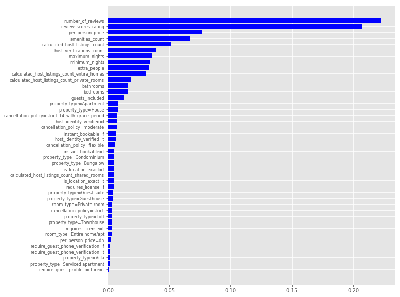

```python
fig, ax = plt.subplots(figsize=(10,10))
ax.invert_yaxis()

y_pos = np.arange(len(tfi['vec_name']))

# Create horizontal bars
plt.barh(y_pos, tfi['tree_fea'], color = 'blue')

# Create names on the x&y-axis
plt.yticks(y_pos, tfi['vec_name'], fontsize=8)
plt.xticks(fontsize=10)

# Show graphic
plt.show()
```

Among all the features, 'number_of_reviews' and 'review_scores_rating' contributed the most importance, both exceeding 0.2. After them are features related to per person price, amenities, host verification methods and living nights.

**Random Forest Classifier**

```python
from sklearn.ensemble import RandomForestClassifier
```

```python
forest=RandomForestClassifier(n_estimators=10)
```

```python
forest.fit(train_d,train_lab)
```

```
RandomForestClassifier(bootstrap=True, class_weight=None, criterion='gini',
            max_depth=None, max_features='auto', max_leaf_nodes=None,
            min_impurity_decrease=0.0, min_impurity_split=None,
            min_samples_leaf=1, min_samples_split=2,
            min_weight_fraction_leaf=0.0, n_estimators=10, n_jobs=1,
            oob_score=False, random_state=None, verbose=0,
            warm_start=False)
```

```python
forest.score(test_d, test_lab)
```

```
0.8454682254890612
```

```python
predictions = forest.predict(test_d)
predicted = pd.DataFrame(list(le.inverse_transform(predictions)))
test_data = pd.DataFrame(list(le.inverse_transform(test_lab)))
test_data.rename(columns={0: 'host_is_superhost'}, inplace=True)
result=pd.concat([test_data,predicted],axis=1)
result.rename(columns={0: 'predicted'}, inplace=True)
result.head()
```

[output not shown]

|  | host_is_superhost | predicted |
| --- | --- | --- |
| 0 | f | f |
| 1 | f | f |
| 2 | f | f |
| 3 | f | f |
| 4 | f | f |

```python
confusion_matrix = metrics.confusion_matrix(test_lab, predictions)
```

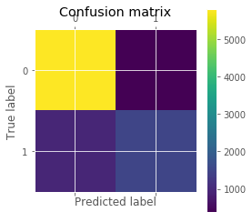

```python
plt.matshow(confusion_matrix)
plt.title('Confusion matrix')
plt.colorbar()
plt.ylabel('True label')
plt.xlabel('Predicted label')
plt.show()
```

```python
print (metrics.classification_report(test_lab, predictions))
```

```
             precision    recall  f1-score   support

          0       0.86      0.94      0.90      6173
          1       0.80      0.61      0.69      2466

avg / total       0.84      0.85      0.84      8639
```

```python
forest_fea = forest.feature_importances_.tolist()
```

```python
ffi = pd.DataFrame({'vec_name': vec_name, 'forest_fea': forest_fea})
ffi = ffi.sort_values(by='forest_fea', ascending=False)
ffi = ffi[ffi.forest_fea > 0.001]
ffi.head()
```

|  | vec_name | forest_fea |
| --- | --- | --- |
| 36 | number_of_reviews | 0.1641 |
| 89 | review_scores_rating | 0.1540 |
| 0 | amenities_count | 0.0896 |
| 37 | per_person_price | 0.0643 |
| 10 | calculated_host_listings_count | 0.0489 |

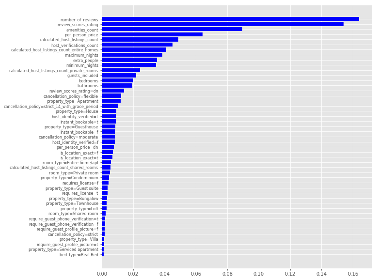

```python
fig, ax = plt.subplots(figsize=(10,10))
ax.invert_yaxis()

y_pos = np.arange(len(ffi['vec_name']))

# Create horizontal bars
plt.barh(y_pos, ffi['forest_fea'], color = 'blue')

# Create names on the x&y-axis
plt.yticks(y_pos, ffi['vec_name'], fontsize=8)
plt.xticks(fontsize=10)

# Show graphic
plt.show()
```

Among all the features, 'number_of_reviews' and 'review_scores_rating' contributed the most importance, both exceeding 0.15. After them are features related to amenities, per person price, host verification methods and living nights.

**Comprehensive Analysis of Results**

Combining the processing results of the two classifiers can lead to some consistent conclusions. The classifier is more accurate in predicting non-superhost. One possibility is that some superhosts whose conditions are not met criteria can be more clearly identified by the classifier. The reason for the relatively inaccurate prediction of superhost may be that the rating criteria set by Airbnb have not been met, and this part (stays and cancellations) of the data is not used in the analysis.

The classifier's ordering for feature importance can correspond to some of the contents of the literature review to some extent. Despite the integration of individual features for holistic analysis, which contains many different factors, **some key considered features are still the same, such as price, minimum stays (Rimer, 2017) and satisfaction ((related to reviews) Nguyen, 2016). This corroborates whether the host can become a superhost actually has a connection with the tenant's demands.** On the one hand, tenants have some common priority needs (price and minimum stays). On the other hand, for tenants with different needs, reviews reflects their satisfaction.

**Results Comparison (Classifier Selection)**

In the accuracy of the prediction results, the two classifiers are different; in the ranking of feature importance, the two classifiers are basically the same. Therefore, in the selection of a more efficient classifier between these two, only the results of the accuracy section will be referred to.

Random Forest is better at predicting the average accuracy of the overall data. For non-superhost precision, the predictions of the two classifiers are roughly the same; for non-superhost recall, Random Forest is higher than Decision Tree; for superhost precision, Random Forest is also higher than Decision Tree; for superhost recall, Decision Tree is higher than Random Forest. **Therefore, Random Forest has more advantages.**

**Limitation and Future Study**

1. The parameters of the classifier have not been deeper tested and modified. It is a part that can be optimised later.
2. For the treatment of unknown data, the research adopts the 'dn' substitution, which may affect the accuracy of the results to some extent.
3. Due to the different attributes of the research selected features, there is no standardisation to features, which may affect the results.
4. The study chooses to retain the review data. In the results presentation, the importance of review related features to the classification is more significant than other features. This part can make better improvements in future in-depth research and further divest the corresponding data. For example, to get more detailed comments and distinguish by identifying the content, rather than just using scores.

**Conclusion**

The research identified the Random Forest as a relatively more efficient classifier by collating and analysing the data. Through the analysis of each feature, it can know whether the host can become a superhost is affected by multiple features. There is a certain connection between it and tenant demands. Satisfaction, amenities and prices have become the most important features. In addition, geographical factors have also been proven to be no direct connection with whether host can become superhost. Research also has some parts that can be improved, which provides direction for more in-depth research in the future.

**References**

Airbnb (2019) *Superhost: Recognising the best in hospitality*. [Online]. Available: https://www.airbnb.co.uk/superhost.

Guttentag, D.A. (2016) *Why tourists choose Airbnb: A motivation-based segmentation study underpinned by innovation concepts*. Waterloo: University of Waterloo.

Inside Airbnb (2019) *Get the Data: Los Angeles, California, United States*. [Online]. Available: http://insideairbnb.com/get-the-data.html.

Nguyen, H.N. (2016) *Customer value in sharing economy the case of airbnb*. Tampere: University of Tampere.

Nguyen, Q. (2014) *A Study of Airbnb as a Potential Competitor of the Hotel Industry*. Las Vegas: University of Nevada.

Quattrone, G., Proserpio, D., Quercia, D., Capra, L. and Musolesi, M. (2016) *Who Benefits from the 'Sharing' Economy of Airbnb*. London: University College London.

Reid, C.P. (2018) *Exploring and Visualizing Chicago Transit data using pandas and Bokeh — Part II (intro to Bokeh)*. [Online]. Available: https://towardsdatascience.com/exploring-and-visualizing-chicago-transit-data-using-pandas-and-bokeh-part-ii-intro-to-bokeh-5dca6c5ced10.

Rimer, R.S. (2017) *Why do people choose to stay with Airbnb*. Vienna: Modul University Vienna.

Tepavcevic, J., Blesic, I., Bradic, M., Ivkov, M. and Stefanovic, V. (2016) 'Importance of location and exterior of city hotels as elements of guest satisfaction'. *Arhitektura i urbanizam*, 2016:7-16.